# Titanic

Gilbert Toroitich Tarus

14/04/2021

## **Introduction**

This is a submission for the final project in Coursera’s Practical Machine Learning by Johns Hopkins University, third course in the Data Science: Statistics and Machine Learning Specialization.

This is a submission for the machine learning competition on https://www.kaggle.com/. The aim of this competition is use machine learning to create a model that predicts which passengers survived the Titanic shipwreck.

### **Summary**

In this report, we trained five models: **Generalized Linear Model (GLM)**,**Random Forest**,**Decision Trees**, **Support Vector Machine (svm)** and **Gradient Boost Model** using k-folds cross validation for purposes of reducing noise and obtaining patterns in the training data. This models were chosen because the outcome variable is a class variable. We split the train.csv data set into training and validation sets. The test.csv data set provided was left for the purposes of the final prediction.

### **Data**

The training data for this project are available here:

https://www.kaggle.com/c/titanic/data?select=train.csv

The test data are available here:

https://www.kaggle.com/c/titanic/data?select=test.csv

MOre information for this competition and data are found here:

https://www.kaggle.com/c/titanic/overview

#### **Load the required packages**

```r
library(caret);library(ggplot2);library(dplyr)
library(skimr)
library(naniar)
library(kernlab)
library(randomForest)
library(rattle)
```

## **Getting Data and cleaning data**

```r
tit_train <- read.csv("data/train.csv")
tit_test <- read.csv("data/test.csv")
dim(tit_train);dim(tit_test)
```

```
## [1] 891  12
```

```
## [1] 418  11
```

```r
view(head(tit_train[complete.cases(tit_train),],10))
```

```r
names(tit_train)
```

```
##  [1] "PassengerId" "Survived"    "Pclass"      "Name"        "Sex"
##  [6] "Age"         "SibSp"       "Parch"       "Ticket"      "Fare"
## [11] "Cabin"       "Embarked"
```

```r
glimpse(tit_train)
```

```
## Rows: 891
## Columns: 12
## $ PassengerId <int> 1, 2, 3, 4, 5, 6, 7, 8, 9, 10, 11, 12, 13, 14, 15, 16, 17,~
## $ Survived    <int> 0, 1, 1, 1, 0, 0, 0, 0, 1, 1, 1, 1, 0, 0, 0, 1, 0, 1, 0, 1~
## $ Pclass      <int> 3, 1, 3, 1, 3, 3, 1, 3, 3, 2, 3, 1, 3, 3, 3, 2, 3, 2, 3, 3~
## $ Name        <chr> "Braund, Mr. Owen Harris", "Cumings, Mrs. John Bradley (Fl~
## $ Sex         <chr> "male", "female", "female", "female", "male", "male", "mal~
## $ Age         <dbl> 22, 38, 26, 35, 35, NA, 54, 2, 27, 14, 4, 58, 20, 39, 14, ~
## $ SibSp       <int> 1, 1, 0, 1, 0, 0, 0, 3, 0, 1, 1, 0, 0, 1, 0, 0, 4, 0, 1, 0~
## $ Parch       <int> 0, 0, 0, 0, 0, 0, 0, 1, 2, 0, 1, 0, 0, 5, 0, 0, 1, 0, 0, 0~
## $ Ticket      <chr> "A/5 21171", "PC 17599", "STON/O2. 3101282", "113803", "37~
## $ Fare        <dbl> 7.2500, 71.2833, 7.9250, 53.1000, 8.0500, 8.4583, 51.8625,~
## $ Cabin       <chr> "", "C85", "", "C123", "", "", "E46", "", "", "", "G6", "C~
## $ Embarked    <chr> "S", "C", "S", "S", "S", "Q", "S", "S", "S", "C", "S", "S"~
```

```r
summary(tit_train)
```

```
##   PassengerId       Survived          Pclass          Name
##  Min.   :  1.0   Min.   :0.0000   Min.   :1.000   Length:891
##  1st Qu.:223.5   1st Qu.:0.0000   1st Qu.:2.000   Class :character
##  Median :446.0   Median :0.0000   Median :3.000   Mode  :character
##  Mean   :446.0   Mean   :0.3838   Mean   :2.309
##  3rd Qu.:668.5   3rd Qu.:1.0000   3rd Qu.:3.000
##  Max.   :891.0   Max.   :1.0000   Max.   :3.000
##
##      Sex                 Age            SibSp           Parch
##  Length:891         Min.   : 0.42   Min.   :0.000   Min.   :0.0000
##  Class :character   1st Qu.:20.12   1st Qu.:0.000   1st Qu.:0.0000
##  Mode  :character   Median :28.00   Median :0.000   Median :0.0000
##                     Mean   :29.70   Mean   :0.523   Mean   :0.3816
##                     3rd Qu.:38.00   3rd Qu.:1.000   3rd Qu.:0.0000
##                     Max.   :80.00   Max.   :8.000   Max.   :6.0000
##                     NA's   :177
##     Ticket               Fare           Cabin             Embarked
##  Length:891         Min.   :  0.00   Length:891         Length:891
##  Class :character   1st Qu.:  7.91   Class :character   Class :character
##  Mode  :character   Median : 14.45   Mode  :character   Mode  :character
##                     Mean   : 32.20
##                     3rd Qu.: 31.00
##                     Max.   :512.33
##
```

##### **Removing unnecessary and missing variables.**

For this submission, we cannot do much transformation on PassengerId, Name and Ticket variables in the data. For the purposes of modeling, we remove this variables from the data.

```r
tit_train <- tit_train %>% select(-PassengerId,-Name,-Ticket, -Cabin)
```

##### **Check for the missing values**

```r
tit_train %>% miss_var_summary()
```

```
## # A tibble: 8 x 3
##   variable n_miss pct_miss
##   <chr>     <int>    <dbl>
## 1 Age         177     19.9
## 2 Survived      0      0
## 3 Pclass        0      0
## 4 Sex           0      0
## 5 SibSp         0      0
## 6 Parch         0      0
## 7 Fare          0      0
## 8 Embarked      0      0
```

The variable age has 177 missing values. This is about 19.87% of the data. Since this value is not large enough to omit, we may choose to impute the missing values with the **mean** or **median**. To chose the better measure, we may have a look at the distribution of age.

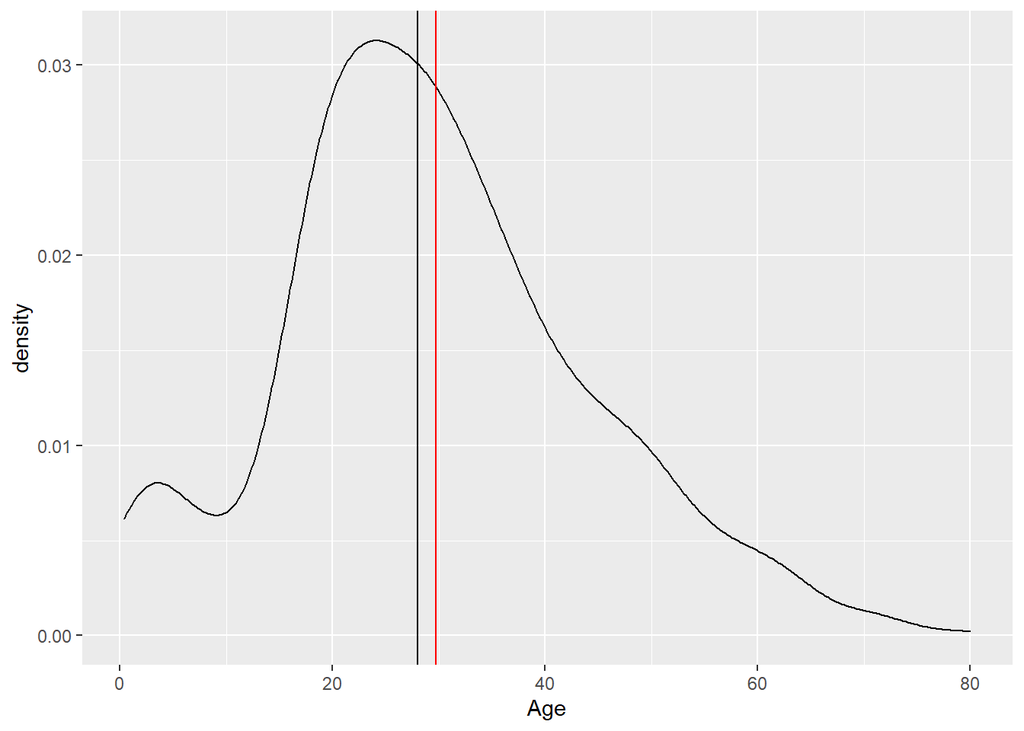

```r
ggplot(tit_train,aes(x = Age))+
 geom_density()+
 geom_vline(xintercept =c(mean(tit_train$Age,na.rm = TRUE), median(tit_train$Age, na.rm = TRUE)), color= c("red","black"))
```

The two measures are close to each other. We can their choose any of them. Here we will choose to use the median to impute for the missing values.

```r
tit_train <- tit_train %>% impute_median_all()
tit_test <- tit_test %>% impute_median_all()
```

##### **Preprocessing**

```r
# Factor variables
tit_train <- tit_train %>%
 mutate(Pclass = as.factor(Pclass), Sex = as.factor(Sex),Parch = as.factor(Parch), Embarked = as.factor(Embarked),Survived = as.factor(Survived))
tit_test <- tit_test %>%
 mutate(Pclass = as.factor(Pclass), Sex = as.factor(Sex),Parch = as.factor(Parch), Embarked = as.factor(Embarked))

levels(tit_train$Parch) <- c("0", "1", "2", "3", "4", "5", "6","9")
```

**Removing zero and near zero variance predictors**

```r
nzv <- nearZeroVar(tit_train)
nzv
```

```
## integer(0)
```

From the above output, there are no zero and near zero variance variables.

**Check for correlated data**

```r
num <- select_if(tit_train,is.numeric)
highCor<- findCorrelation(cor(num),cutoff = 0.9)
highCor
```

```
## integer(0)
```

The ouput above shows that there are no correlated data.

## **Splitting data to training and validation sets**

We can now split the data **tit_train** to **training** and **validation** data sets. However, the test set (**“tit_test”**) will be left for the final prediction.

```r
inTrain <- createDataPartition(y=tit_train$Survived, p=0.75, list=FALSE)
training <- tit_train[inTrain,]
validation <- tit_train[-inTrain,]
```

## **Modeling**

### **Cross validation**

To obtain the correct patterns from the data and ensure it is not getting too much noise, we use k-folds cross validation technique.

```r
train_control <- trainControl(method="cv", number=5)
```

### **Generalized Linear Model**

```r
glmFit <- train(Survived ~ ., data = training, method = "glm", family = "binomial", trControl = train_control)
# Predict probabilities
glmPred <- predict(glmFit, validation)
cmGlm <- confusionMatrix(glmPred,validation$Survived)
cmGlm
```

```
## Confusion Matrix and Statistics
##
##           Reference
## Prediction   0   1
##          0 119  30
##          1  18  55
##
##                Accuracy : 0.7838
##                  95% CI : (0.7238, 0.8361)
##     No Information Rate : 0.6171
##     P-Value [Acc > NIR] : 8.045e-08
##
##                   Kappa : 0.5299
##
##  Mcnemar's Test P-Value : 0.1124
##
##             Sensitivity : 0.8686
##             Specificity : 0.6471
##          Pos Pred Value : 0.7987
##          Neg Pred Value : 0.7534
##              Prevalence : 0.6171
##          Detection Rate : 0.5360
##    Detection Prevalence : 0.6712
##       Balanced Accuracy : 0.7578
##
##        'Positive' Class : 0
##
```

The GML model above as an accuracy of 78.38% and an out of sample error of about 21.62%. This is relative low.

### **Random Forest Model**

```r
rfMod <- train(Survived ~., data=training, method="rf", trControl = train_control, tuneLength = 5)

rfPred <- predict(rfMod, validation)
cmRF <- confusionMatrix(rfPred, validation$Survived)
cmRF
```

```
## Confusion Matrix and Statistics
##
##           Reference
## Prediction   0   1
##          0 121  29
##          1  16  56
##
##                Accuracy : 0.7973
##                  95% CI : (0.7383, 0.8481)
##     No Information Rate : 0.6171
##     P-Value [Acc > NIR] : 6.056e-09
##
##                   Kappa : 0.5582
##
##  Mcnemar's Test P-Value : 0.07364
##
##             Sensitivity : 0.8832
##             Specificity : 0.6588
##          Pos Pred Value : 0.8067
##          Neg Pred Value : 0.7778
##              Prevalence : 0.6171
##          Detection Rate : 0.5450
##    Detection Prevalence : 0.6757
##       Balanced Accuracy : 0.7710
##
##        'Positive' Class : 0
##
```

The random forest model above as an accuracy of 79.73% and an out of sample error of about 20.27% . This is relative high accuracy.

### **Decision Tree**

```r
treeMod <- train(Survived~., data=training, method="rpart", trControl = train_control, tuneLength = 5)
#Prediction
predTrees <- predict(treeMod, validation)
cmTrees <- confusionMatrix(predTrees, validation$Survived)
cmTrees
```

```
## Confusion Matrix and Statistics
##
##           Reference
## Prediction   0   1
##          0 117  30
##          1  20  55
##
##                Accuracy : 0.7748
##                  95% CI : (0.7141, 0.828)
##     No Information Rate : 0.6171
##     P-Value [Acc > NIR] : 3.964e-07
##
##                   Kappa : 0.5125
##
##  Mcnemar's Test P-Value : 0.2031
##
##             Sensitivity : 0.8540
##             Specificity : 0.6471
##          Pos Pred Value : 0.7959
##          Neg Pred Value : 0.7333
##              Prevalence : 0.6171
##          Detection Rate : 0.5270
##    Detection Prevalence : 0.6622
##       Balanced Accuracy : 0.7505
##
##        'Positive' Class : 0
##
```

## **Support Vector Machine**

```r
svmMod <- train(Survived ~., data=training, method="svmRadial", trControl = train_control, tuneLength = 5, verbose = FALSE)

# Prediction
predSvm <- predict(svmMod, validation)

#Confusion matrix
cmSvm <- confusionMatrix(predSvm,validation$Survived)
cmSvm
```

```
## Confusion Matrix and Statistics
##
##           Reference
## Prediction   0   1
##          0 117  28
##          1  20  57
##
##                Accuracy : 0.7838
##                  95% CI : (0.7238, 0.8361)
##     No Information Rate : 0.6171
##     P-Value [Acc > NIR] : 8.045e-08
##
##                   Kappa : 0.5341
##
##  Mcnemar's Test P-Value : 0.3123
##
##             Sensitivity : 0.8540
##             Specificity : 0.6706
##          Pos Pred Value : 0.8069
##          Neg Pred Value : 0.7403
##              Prevalence : 0.6171
##          Detection Rate : 0.5270
##    Detection Prevalence : 0.6532
##       Balanced Accuracy : 0.7623
##
##        'Positive' Class : 0
##
```

## **GBM**

```r
gbmMod <- train(Survived ~., data=training, method="gbm", trControl = train_control, tuneLength = 5, verbose = FALSE)

# Prediction
predGbm <- predict(gbmMod, validation)

#Confusion matrix
cmGbm <- confusionMatrix(predGbm,validation$Survived)
cmGbm
```

```
## Confusion Matrix and Statistics
##
##           Reference
## Prediction   0   1
##          0 126  31
##          1  11  54
##
##                Accuracy : 0.8108
##                  95% CI : (0.753, 0.8601)
##     No Information Rate : 0.6171
##     P-Value [Acc > NIR] : 3.572e-10
##
##                   Kappa : 0.5809
##
##  Mcnemar's Test P-Value : 0.00337
##
##             Sensitivity : 0.9197
##             Specificity : 0.6353
##          Pos Pred Value : 0.8025
##          Neg Pred Value : 0.8308
##              Prevalence : 0.6171
##          Detection Rate : 0.5676
##    Detection Prevalence : 0.7072
##       Balanced Accuracy : 0.7775
##
##        'Positive' Class : 0
##
```

**Accuracy and Out of Sample Error**

```r
GLM <- c(cmGlm$overall["Accuracy"],1-c(cmGlm$overall["Accuracy"]))
DTree <- c(cmTrees$overall["Accuracy"],1-c(cmTrees$overall["Accuracy"]))
RF <- c(cmRF$overall["Accuracy"],1-c(cmRF$overall["Accuracy"]))
SVM <- c(cmSvm$overall["Accuracy"],1-c(cmSvm$overall["Accuracy"]))
GBM <- c(cmGbm$overall["Accuracy"],1-c(cmGbm$overall["Accuracy"]))

Output <- rbind(GLM,DTree,RF,SVM,GBM)
colnames(Output) <- c("Accuracy","oo_S_Err")

Output <- Output %>% apply(.,2, round,3)
Output[order(-Output[,1]),]
```

```
##       Accuracy oo_S_Err
## GBM      0.811    0.189
## RF       0.797    0.203
## GLM      0.784    0.216
## SVM      0.784    0.216
## DTree    0.775    0.225
```

The best model is the Gradient Boosting Machines model, with 0.8108108 accuracy and 0.1891892 out of sample error rate. We find that to be a sufficient enough model to use for our test sets.

## **Predictions on Test Set**

We will use the Gradient Boosting Machines model to do prediction on the test set since it has the highest accuracy and hence low out of sample error.

## **Gradient Boosting Machines model Predictions on the test set**

```r
testPredGBM <- predict(gbmMod,newdata = tit_test)
```

## **Appendix**

**Feature Plot**

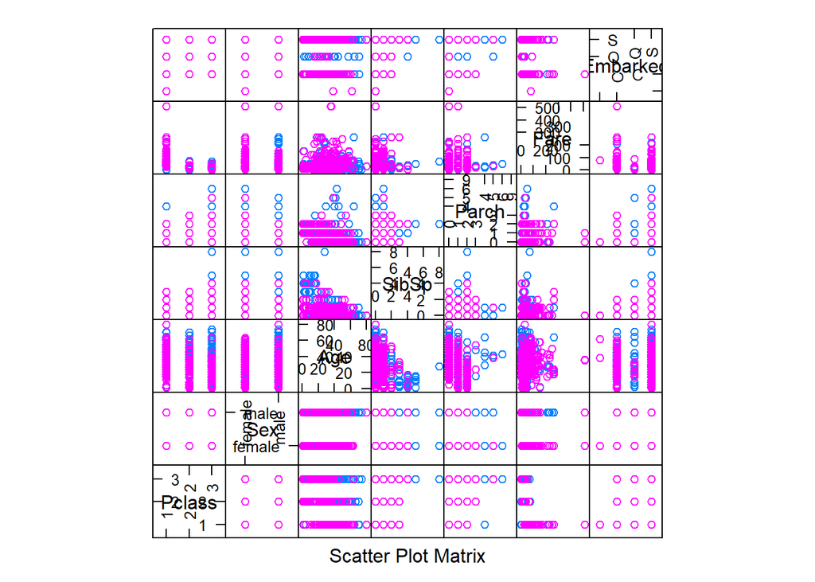

```r
featurePlot(x = tit_train[,-1], y = tit_train$Survived,plot = "pairs")
```

**correlation matrix of variables in training set**

```r
library(psych)
```

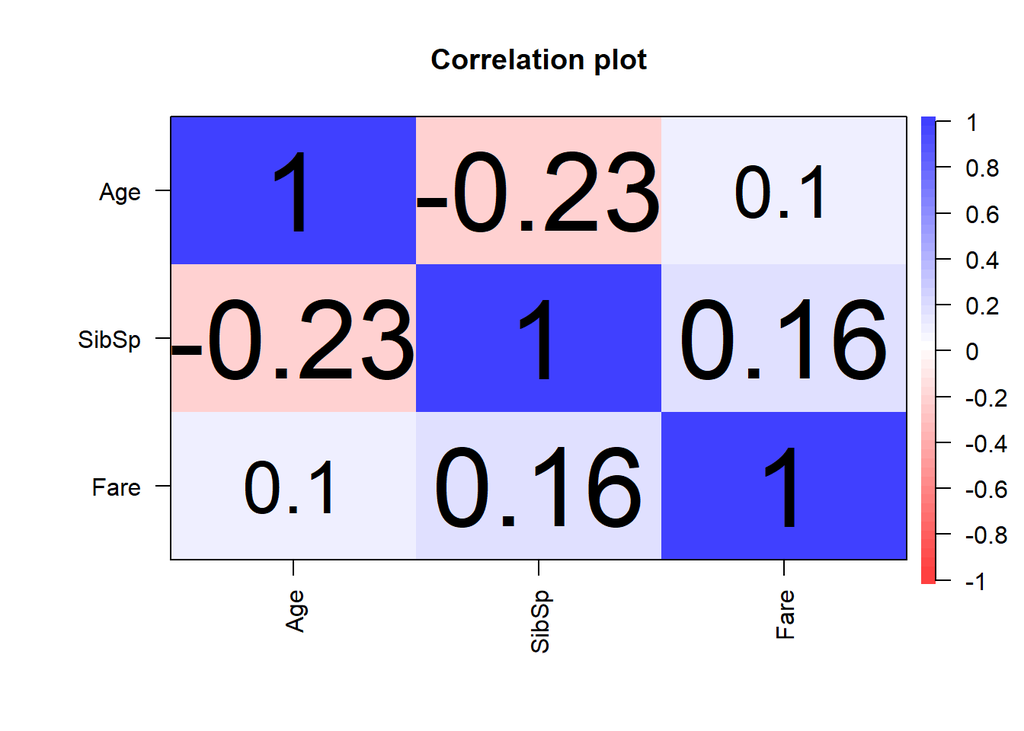

```r
cor.plot(num,xlas = 2)
```

Plotting the models

#### **Random Forest model**

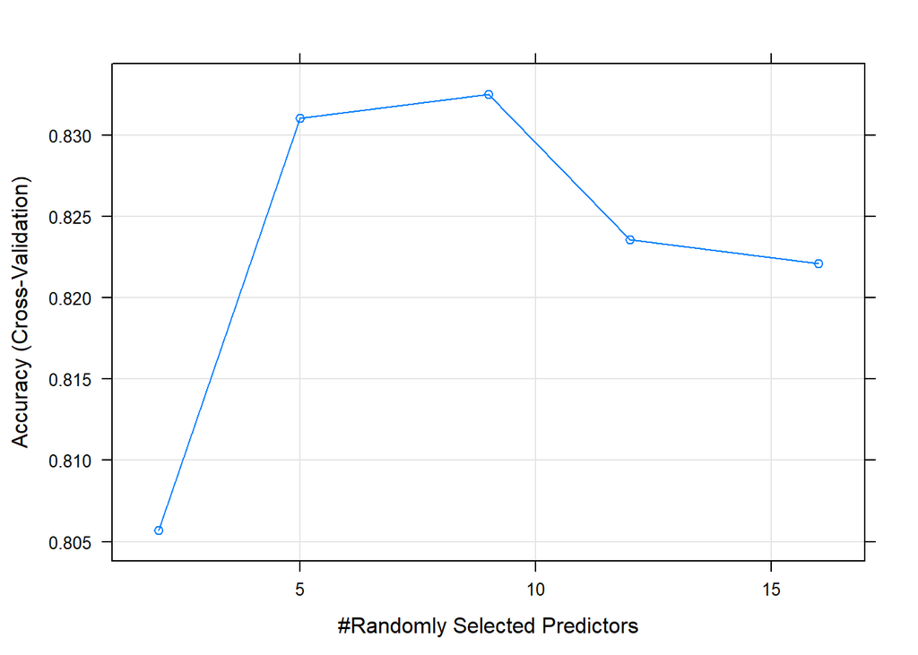

```r
plot(rfMod)
```

#### **Decision Trees**

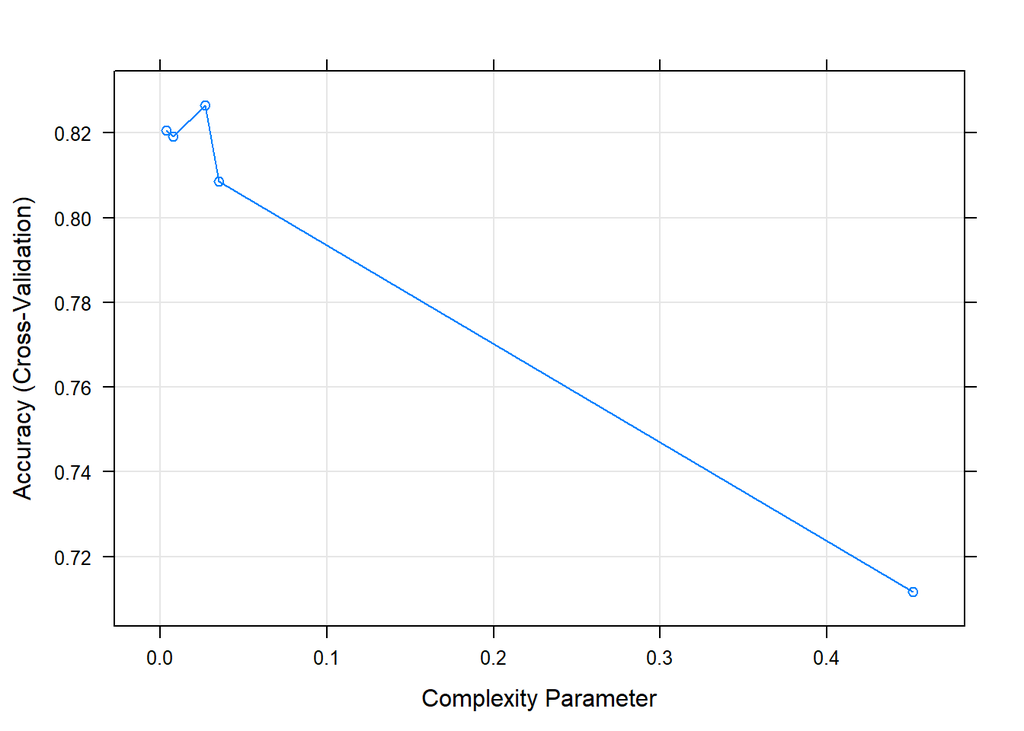

```r
plot(treeMod)
```

[figure not shown]

```r
fancyRpartPlot(treeMod$finalModel)
```

#### **Support Vector Machine**

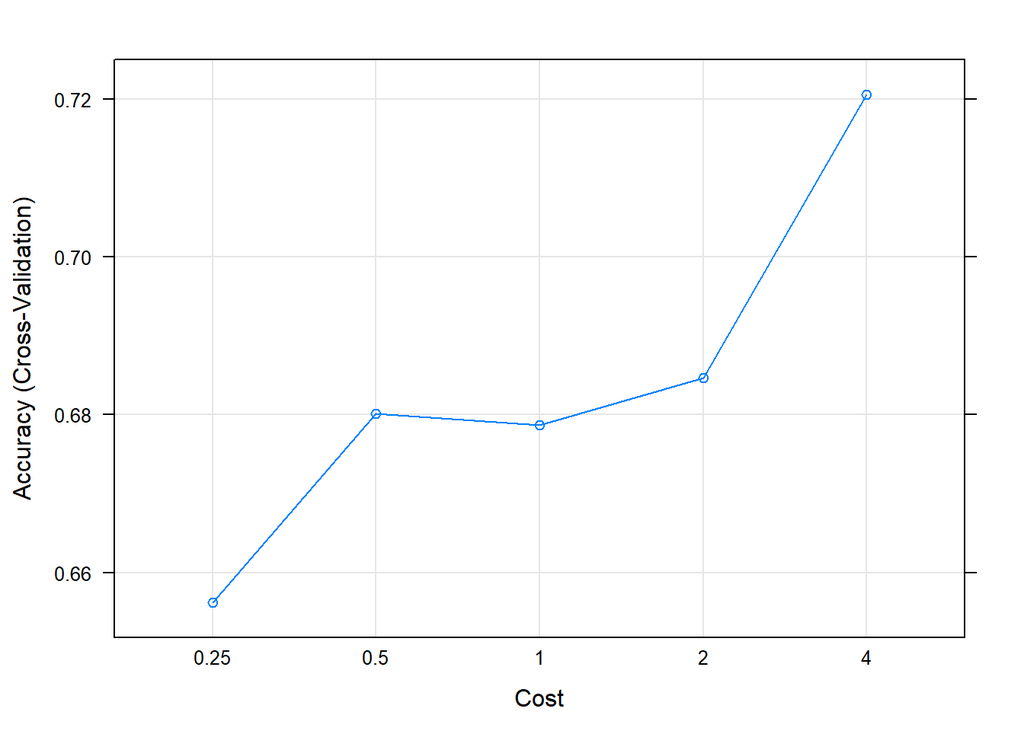

```r
plot(svmMod, plotType = "line")
```